# 20170720 - Do You Get What You Want

Anandini, Thoa

7/20/2020

### Read in data from HSAPS and June Biog

Here we read in HSAPS data from 2008 to 2015 (in academic year term: 2008-09 to 2015-16) because they have small proportion of NAs in `final_disposition`.

We choose the following colums:

- `r1programcode*` : specify the program that a student ranks and applies to in the first round.
- `final_disposition`: specify the program that a student gets finalized to.

Then we read in June Biog data to have students’ demographics.

### What percentage of applicants not listing all 12 choice?

```r
# ~ 85% not filled out 12th choice.
satisfied_08_15 %>%
  group_by(is.na(r1programcode12)) %>%
  count()

# ~ 80% not filled out 11th choice.
satisfied_08_15 %>%
  group_by(is.na(r1programcode11)) %>%
  count()

# ~ 75% not filled out 10th choice.
satisfied_08_15 %>%
  group_by(is.na(r1programcode10)) %>%
  count()

# ~ 69% not filled out 9th choice
satisfied_08_15 %>%
  group_by(is.na(r1programcode9)) %>%
  count()

# ~ 62% not filled out 8th choice
satisfied_08_15 %>%
  group_by(is.na(r1programcode8)) %>%
  count()

# ~ 53% not filled out 7th choice
satisfied_08_15 %>%
  group_by(is.na(r1programcode7)) %>%
  count()

# ~ 42% not filled out 6th choice
satisfied_08_15 %>%
  group_by(is.na(r1programcode6)) %>%
  count()

# ~ 32% not filled out 5th choice
satisfied_08_15 %>%
  group_by(is.na(r1programcode5)) %>%
  count()

# ~ 26% not filled out 4th choice
satisfied_08_15 %>%
  group_by(is.na(r1programcode4)) %>%
  count()
```

[output not shown]

### Calculating the `was_satisfied` metrics

```
##   k_value percent_students_satisfied
## 1      12                  0.7534761
## 2       6                  0.7198726
## 3       3                  0.6175062
## 4       1                  0.4070151
```

### Join HSAPS and June Bio data, on student_id and year.

Will drop 85,205 rows whose `student_id_scram` correspoding with `year` are not exist in June Biog.

```r
summary(withfeatures_satisfied_08_15)
```

```
##       year      student_id_scram   grade_level            dbn
##  Min.   :2008   Length:570910      Length:570910      Length:570910
##  1st Qu.:2010   Class :character   Class :character   Class :character
##  Median :2012   Mode  :character   Mode  :character   Mode  :character
##  Mean   :2012
##  3rd Qu.:2014
##  Max.   :2015
##      sex             ethnicity              ell              swd
##  Length:570910      Length:570910      Min.   :0.0000   Min.   :0.0000
##  Class :character   Class :character   1st Qu.:0.0000   1st Qu.:0.0000
##  Mode  :character   Mode  :character   Median :0.0000   Median :0.0000
##                                        Mean   :0.1207   Mean   :0.1745
##                                        3rd Qu.:0.0000   3rd Qu.:0.0000
##                                        Max.   :1.0000   Max.   :1.0000
##   home_lang         was_satisfied_top12 was_satisfied_top6
##  Length:570910      Min.   :0.0000      Min.   :0.0000
##  Class :character   1st Qu.:1.0000      1st Qu.:0.0000
##  Mode  :character   Median :1.0000      Median :1.0000
##                     Mean   :0.7815      Mean   :0.7475
##                     3rd Qu.:1.0000      3rd Qu.:1.0000
##                     Max.   :1.0000      Max.   :1.0000
##  was_satisfied_top3 was_satisfied_top1
##  Min.   :0.000      Min.   :0.0000
##  1st Qu.:0.000      1st Qu.:0.0000
##  Median :1.000      Median :0.0000
##  Mean   :0.643      Mean   :0.4256
##  3rd Qu.:1.000      3rd Qu.:1.0000
##  Max.   :1.000      Max.   :1.0000
```

```r
# 52 students have NA in home language
withfeatures_satisfied_08_15 %>%
  filter(is.na(home_lang))
```

```
## # A tibble: 52 x 13
##     year student_id_scram grade_level    dbn   sex ethnicity   ell   swd
##    <dbl>            <chr>       <chr>  <chr> <chr>     <chr> <int> <int>
##  1  2008        722612843          08 10X390     M  Hispanic     0     0
##  2  2009        819202249          08 01M140     M  Hispanic     0     0
##  3  2009        392472738          08 10X331     M  Hispanic     1     0
##  4  2009        103472738          08 09X215     M  Hispanic     0     0
##  5  2010        496302197          08 30Q145     F     Asian     0     0
##  6  2010        295602060          08 03M333     M     Black     0     0
##  7  2010        373612943          08 30Q145     F  Hispanic     0     0
##  8  2010        712022493          08 84X488     M     Black     0     1
##  9  2011        496302197          08 30Q145     F     Asian     0     0
## 10  2012        944502708          08 15K821     F  Hispanic     0     0
## # ... with 42 more rows, and 5 more variables: home_lang <chr>,
## #   was_satisfied_top12 <dbl>, was_satisfied_top6 <dbl>,
## #   was_satisfied_top3 <dbl>, was_satisfied_top1 <dbl>
```

```r
# so we'll drop these rows with NA's in home language, before we put it into our model
withfeatures_satisfied_08_15 <-
  withfeatures_satisfied_08_15 %>%
  filter(!is.na(home_lang))

withfeatures_satisfied_08_15 %>%
  group_by(grade_level) %>%
  count()
```

```
## # A tibble: 12 x 2
## # Groups:   grade_level [12]
##    grade_level      n
##          <chr>  <int>
##  1          02      5
##  2          03      3
##  3          04      1
##  4          06      6
##  5          07     85
##  6          08 570664
##  7          09     29
##  8          0K      3
##  9          10     54
## 10          11      3
## 11          12      4
## 12          PK      1
```

```r
withfeatures_satisfied_08_15 %>%
  group_by(ethnicity) %>%
  count()
```

```
## # A tibble: 7 x 2
## # Groups:   ethnicity [7]
##         ethnicity      n
##             <chr>  <int>
## 1               .    254
## 2           Asian  87834
## 3           Black 170871
## 4        Hispanic 229012
## 5    Multi-Racial   1398
## 6 Native American   3216
## 7           White  78273
```

### Starting our regression!

[figure not shown]

```r
library(glmnet)
library(scales)
library(ROCR)
library(Matrix)

############ Model R #################
library(modelr)

frmula_top12 <- as.formula(was_satisfied_top12 ~ as.factor(year) + sex + ethnicity + ell + swd)
frmula_top1 <- as.formula(was_satisfied_top1 ~ as.factor(year) + sex + ethnicity + ell + swd)

mooo_top12 <- model.matrix(object = frmula_top12,
                     data = withfeatures_satisfied_08_15)
mooo_top1 <- model.matrix(object = frmula_top1,
                     data = withfeatures_satisfied_08_15)

logit_satisfied_top12 <- glmnet(x = mooo_top12,
                          y = withfeatures_satisfied_08_15$was_satisfied_top12,
                          family = "binomial",
                          lambda = 0)
logit_satisfied_top1 <- glmnet(x = mooo_top1,
                          y = withfeatures_satisfied_08_15$was_satisfied_top1,
                          family = "binomial",
                          lambda = 0)

plot(logit_satisfied_top12)
```

```r
coef(logit_satisfied_top12)
```

```
## 18 x 1 sparse Matrix of class "dgCMatrix"
##                                   s0
## (Intercept)               1.26432029
## (Intercept)               .
## as.factor(year)2009      -0.07322965
## as.factor(year)2010      -0.22840545
## as.factor(year)2011      -0.42160121
## as.factor(year)2012      -0.48268750
## as.factor(year)2013      -0.34692338
## as.factor(year)2014      -0.26158131
## as.factor(year)2015      -0.24795225
## sexM                     -0.09675059
## ethnicityAsian           -0.33654836
## ethnicityBlack            0.41918663
## ethnicityHispanic         0.48695456
## ethnicityMulti-Racial    -0.28232871
## ethnicityNative American  0.18020899
## ethnicityWhite            0.09697797
## ell                       0.24655351
## swd                       0.27726827
```

[figure not shown]

```r
plot(logit_satisfied_top1)
```

```r
coef(logit_satisfied_top1)
```

```
## 18 x 1 sparse Matrix of class "dgCMatrix"
##                                    s0
## (Intercept)              -0.108092968
## (Intercept)               .
## as.factor(year)2009      -0.034004940
## as.factor(year)2010      -0.191570750
## as.factor(year)2011      -0.205595415
## as.factor(year)2012      -0.324730470
## as.factor(year)2013      -0.315232516
## as.factor(year)2014      -0.225080344
## as.factor(year)2015      -0.211033960
## sexM                     -0.005028982
## ethnicityAsian           -0.599579793
## ethnicityBlack           -0.028729721
## ethnicityHispanic         0.027650260
## ethnicityMulti-Racial    -0.168845133
## ethnicityNative American -0.077887814
## ethnicityWhite            0.013094513
## ell                       0.238453565
## swd                       0.320409087
```

From the coefficients, we see that:

To get to your top12 schools:

- In year 2012, your chance of being satisfied was the lowest.
- Being male slightly decreased your chance of being satisfied.
- Being Black or Hispanic increased your chance of being satisfied.
- Being an ELL or student with disability increased your chance of being satisfied.

To get to your top1 schools:

- Year 12 again as the year of least chance of being satisfied.
- The effect of being male on your chance was significantly lowered, compared to the top12 scenario.
- Being Asian decreased your chance.
- Similar as above, being an ELL or student with disability increased your chance of being satisfied. Could it be becaues ELL’s and SWD’s generally have fewer choices, therefore they tend to list programs/schools that they are highly suitable for?

```r
(baseline_accuracy_top12 <- mean(withfeatures_satisfied_08_15$was_satisfied_top12))
```

```
## [1] 0.7815183
```

```r
(baseline_accuracy_top1 <- mean(withfeatures_satisfied_08_15$was_satisfied_top1))
```

```
## [1] 0.425619
```

```r
df <- data.frame(actual_top12 = withfeatures_satisfied_08_15$was_satisfied_top12,
                 predicted_top12 = predict(object = logit_satisfied_top12, newx = mooo_top12, type = "response"),
                 actual_top1 = withfeatures_satisfied_08_15$was_satisfied_top1,
                 predicted_top1 = predict(object = logit_satisfied_top12, newx = mooo_top1, type = "response"))
summary(df)
```

```
##   actual_top12          s0          actual_top1          s0.1
##  Min.   :0.0000   Min.   :0.5862   Min.   :0.0000   Min.   :0.5862
##  1st Qu.:1.0000   1st Qu.:0.7528   1st Qu.:0.0000   1st Qu.:0.7528
##  Median :1.0000   Median :0.7960   Median :0.0000   Median :0.7960
##  Mean   :0.7815   Mean   :0.7815   Mean   :0.4256   Mean   :0.7815
##  3rd Qu.:1.0000   3rd Qu.:0.8294   3rd Qu.:1.0000   3rd Qu.:0.8294
##  Max.   :1.0000   Max.   :0.9068   Max.   :1.0000   Max.   :0.9068
```

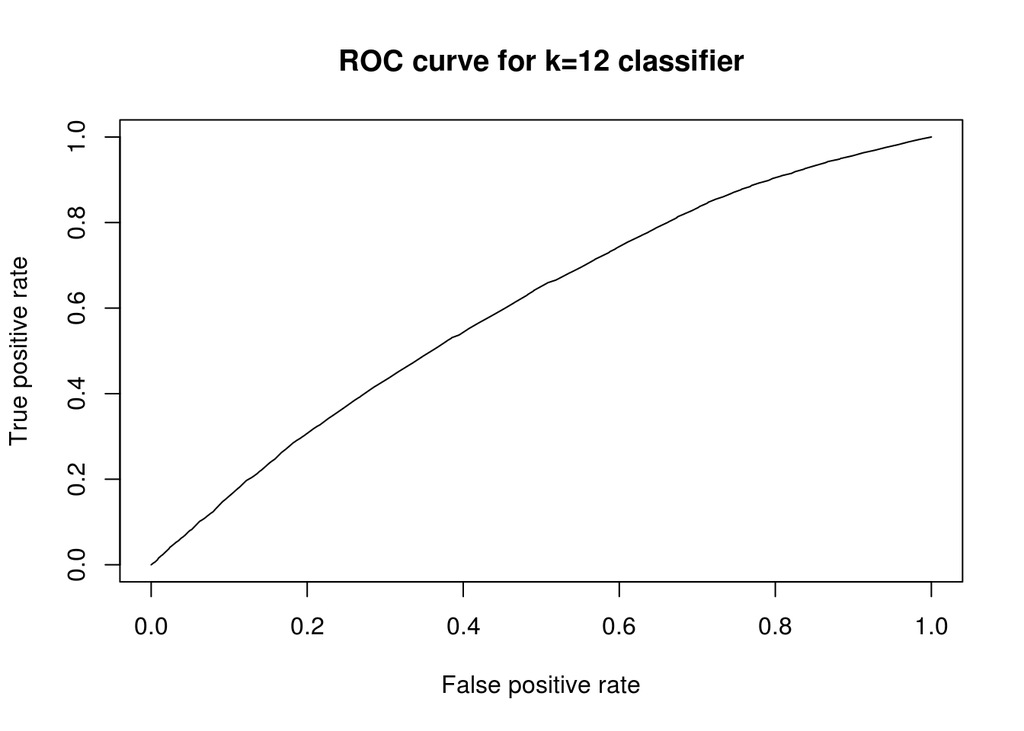

```r
df <-
  df %>%
  rename("predicted_top12" = s0,
         "predicted_top1" = s0.1)
df <-
  df %>%
  mutate(adjusted_pred_top12 = ifelse(predicted_top12 > 0.5, yes=1, no=0),
         adjusted_pred_top1 = ifelse(predicted_top1 < 0.5, yes=1, no=0))


# ROC curve and AUC
pred_top12 <- prediction(df$predicted_top12, df$actual_top12)
perf_top12 <- performance(pred_top12, measure='tpr', x.measure='fpr')

pred_top1 <- prediction(df$predicted_top1, df$actual_top1)
perf_top1 <- performance(pred_top1, measure='tpr', x.measure='fpr')

plot(perf_top12, main = "ROC curve for k=12 classifier")
```

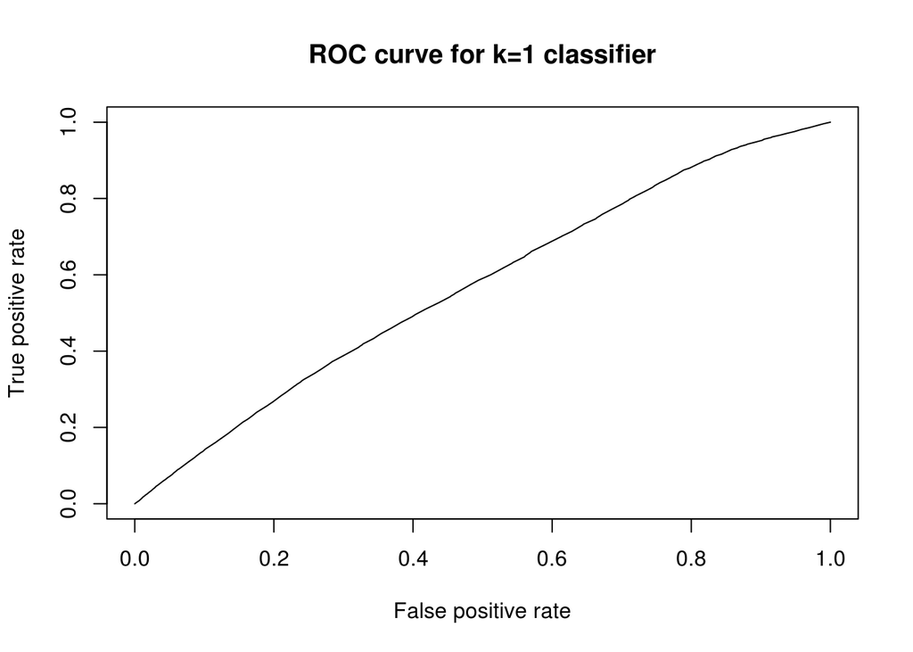

```r
plot(perf_top1, main = "ROC curve for k=1 classifier")
```

```r
performance(pred_top12, 'auc')
```

```
## An object of class "performance"
## Slot "x.name":
## [1] "None"
##
## Slot "y.name":
## [1] "Area under the ROC curve"
##
## Slot "alpha.name":
## [1] "none"
##
## Slot "x.values":
## list()
##
## Slot "y.values":
## [[1]]
## [1] 0.6039839
##
##
## Slot "alpha.values":
## list()
```

```r
performance(pred_top1, 'auc')
```

```
## An object of class "performance"
## Slot "x.name":
## [1] "None"
##
## Slot "y.name":
## [1] "Area under the ROC curve"
##
## Slot "alpha.name":
## [1] "none"
##
## Slot "x.values":
## list()
##
## Slot "y.values":
## [[1]]
## [1] 0.5696987
##
##
## Slot "alpha.values":
## list()
```

```r
# confusion matrix: doesn't work because the packages are missing.
# library(tidyr)
# library(stargazer)
# library(caret)
# confusionMatrix(df$actual_top12, df$predicted_top12)

# manually calculating the confusion matrix:

########### TOP 12 ################
actual_negatives_top12 <- nrow(df) - sum(df$actual_top12)
actual_positives_top12 <- sum(df$actual_top12)

false_negatives_top12 <- nrow(df[which(df$adjusted_pred_top12 == 0 & df$actual_top12 == 1), ])
false_positives_top12 <- nrow(df[which(df$adjusted_pred_top12 == 1 & df$actual_top12 == 0), ])

true_negatives_top12 <- nrow(df[which(df$adjusted_pred_top12 == 0 & df$actual_top12 == 0), ])
true_positives_top12 <- nrow(df[which(df$adjusted_pred_top12 == 1 & df$actual_top12 == 1), ])

# ACCURACY: fraction of correct classifications
(accuracy_top12 <- mean(df$adjusted_pred_top12 == df$actual_top12))
```

```
## [1] 0.7815183
```

```r
# RECALL, SENSITIVITY:
(recall_top12 <- true_positives_top12 / (true_positives_top12 + false_negatives_top12))
```

```
## [1] 1
```

```r
# PRECISION: fraction of positive predictions that are actually true
(precision_top12 <- true_positives_top12 / (true_positives_top12 + false_positives_top12))
```

```
## [1] 0.7815183
```

```r
confMatrix_top12 <-
  matrix(c(true_positives_top12, false_negatives_top12,
           false_positives_top12, true_negatives_top12),
         nrow = 2,
         ncol = 2,
         byrow = TRUE,
         dimnames = list(c("actual=T", "actual=F"),
                         c("predicted=T", "predicted=F")))
confMatrix_top12
```

```
##          predicted=T predicted=F
## actual=T      446136           0
## actual=F      124722           0
```

```r
########### TOP 1 ################
actual_negatives_top1 <- nrow(df) - sum(df$actual_top1)
actual_positives_top1 <- sum(df$actual_top1)

false_negatives_top1 <- nrow(df[which(df$adjusted_pred_top1 == 0 & df$actual_top1 == 1), ])
false_positives_top1 <- nrow(df[which(df$adjusted_pred_top1 == 1 & df$actual_top1 == 0), ])

true_negatives_top1 <- nrow(df[which(df$adjusted_pred_top1 == 0 & df$actual_top1 == 0), ])
true_positives_top1 <- nrow(df[which(df$adjusted_pred_top1 == 1 & df$actual_top1 == 1), ])

# ACCURACY: fraction of correct classifications
(accuracy_top1 <- mean(df$adjusted_pred_top1 == df$actual_top1))
```

```
## [1] 0.574381
```

```r
# RECALL, SENSITIVITY:
(recall_top1 <- true_positives_top1 / (true_positives_top1 + false_negatives_top1))
```

```
## [1] 0
```

```r
# PRECISION: fraction of positive predictions that are actually true
(precision_top1 <- true_positives_top1 / (true_positives_top1 + false_positives_top1))
```

```
## [1] NaN
```

```r
confMatrix_top1 <-
  matrix(c(true_positives_top1, false_negatives_top1,
           false_positives_top1, true_negatives_top1),
         nrow = 2,
         ncol = 2,
         byrow = TRUE,
         dimnames = list(c("actual=T", "actual=F"),
                         c("predicted=T", "predicted=F")))
confMatrix_top1
```

```
##          predicted=T predicted=F
## actual=T           0      242968
## actual=F           0      327890
```

### Note

- where the applicant lives,
- number of choices listed,
- whether they list their local school,
- whether the school listed is more or less selective,
- etc.